# HW1_IS457_33

# Do not remove any of the comments. These are marked by

# HW 1 - Due Monday Sep 17, 2018 in moodle at 1pmCT and hardcopy in class.

# (1). Please upload R code and report to Moodle

# with filename: HW1_IS457_YourClassID.

# (2). Turn in a hard copy of your report in class

# without your name but only your class ID,

# violators will be subject to a points deduction.

## Important: Make sure there is no identifying information on your printout, including name, username etc.

## Only include your class ID on there.

# Part 1. LifeCycleSavings Data

# In this part, we will work with a built-in dataset – LifeCycleSavings.

# (1) R has a built-in help funtion, write your call to the help function below, as well as something

# that you learned about this dataset from the help function. (1 pt)

# Your code/answer here

```r
help("LifeCycleSavings")
```

## I never knew about the life-cycle savings hypothesis, and that it is explained by disposable income and

## change in disposable income across demographic groups of age 0-15 and 75+.

# (2) Describe this dataset (structure, variables, value types, size, etc.) (2 pts)

# Your code/answer here

```r
help("LifeCycleSavings")
```

## This dataset consists of 5 vectors of length 50. These represent the 50 observations of the 5 variables.

## All variables are of the numeric type.

# (3) What is “aggregate personal savings” in this dataset? Calculate the average aggregate

# personal savings of these 50 countries. (1 pt)

# Your code/answer here

## Aggregate personal savings are the variable “sr” in this dataset.

```r
mean(LifeCycleSavings$sr)
```

```
## [1] 9.671
```

# (4) What is “dpi” in this dataset? Find the highest and lowest dpi. (2 pts)

# Your code/answer here

## “dpi” is the amount of real per-capita disposable income averaged over the decade 1960-1970.

```r
min(LifeCycleSavings$dpi)
```

```
## [1] 88.94
```

```r
max(LifeCycleSavings$dpi)
```

```
## [1] 4001.89
```

# (5) How many countries have a dpi above median? (2 pts)

# hint: you might need to find a function to count rows.

# Your code/answer here

```r
median(LifeCycleSavings$dpi)
```

```
## [1] 695.665
```

```r
length(which(LifeCycleSavings$dpi>695.665))
```

```
## [1] 25
```

# (6) What is the highest aggregate personal savings of the countries

# whose pop15s are more than 10 times their pop75s? (2 pts)

# Your code/answer here

```r
max(LifeCycleSavings$sr[LifeCycleSavings$pop15 > 10*LifeCycleSavings$pop75])
```

```
## [1] 21.1
```

# (7) For the countries with dpi above the 75th percentile, what is their average aggregate personal savings?

# For the countries with dpi above the 75th percentale, what is their median aggregate personal savings?

# Why are these two statistics different?

# Your code/answer here

```r
mean(LifeCycleSavings$sr[LifeCycleSavings$dpi > quantile(LifeCycleSavings$dpi, .75)])
```

```
## [1] 10.28154
```

```r
median(LifeCycleSavings$sr[LifeCycleSavings$dpi > quantile(LifeCycleSavings$dpi, .75)])
```

```
## [1] 10.35
```

```r
#These statistics are different because the average is calculated by taking the sum of the observations and
#dividing them by the total number of ovservations, and the median is the value that lies in the middle of
#the data set.
```

# (8) Let’s look at countries with dpi below the 25th percentile. What is their average and their median

# aggregate personal savings?

# Why are these two statistics different? Is the pattern of difference different than what you saw in

# Q7? Why or Why not?

# Your code/answer here

```r
mean(LifeCycleSavings$sr[LifeCycleSavings$dpi < quantile(LifeCycleSavings$dpi, .25)])
```

```
## [1] 7.543846
```

```r
median(LifeCycleSavings$sr[LifeCycleSavings$dpi < quantile(LifeCycleSavings$dpi, .25)])
```

```
## [1] 5.75
```

```r
#These statistics are different because the average is calculated by taking the sum of the observations and
#dividing them by the total number of ovservations, and the median is the value that lies in the middle of
#the data set.
#The pattern of difference is different than Q7 in that the median is signficantly lower than the average.
#One possible explanation of this is that there are more observations of aggregate personal savings with
#lower values, but the observations with higher values are significantly higher observations.
```

# (9). (3 pts)

# Try running each expression in R.

# Record the error message in a comment

# Be sure to directly relate the wording of the error message with

# the problem you find in the expression.

LifeCycleSavings[LifeCycleSavings$pop15 > 10] ### Error message here

```r
#Error in `[.data.frame`(LifeCycleSavings, LifeCycleSavings$pop15 > 10) :
#undefined columns selected
### Explanation here
#The brackets are trying to subset LifeCycleSavings and then looking for the data where it does not exist
#after it was subset. If you remove the brackerst and the first "LifeCycleSavings", you can find out
#which rows have the variable pop15>10.
```

```r
#mean(pop15,pop75)
### Error message here
#Error in mean(pop15, pop75) : object 'pop15' not found
### Explanation here
#This error code comes from there being no information on where to find the variables. This can be included
#by either using $ before each variable or including 'data ='.
```

```r
#mean(LifeCycleSavings$pop15, LifeCycleSavings$pop75)
### Error message here
#Error in mean.default(LifeCycleSavings$pop15, LifeCycleSavings$pop75) :
#'trim' must be numeric of length one
### Explanation here
#This error comes from trying to run two experessions in a function that can only return a "numeric of
#length one" or one response. You can either find the mean of pop15 or pop75, but not both at once.
```

# Part 2. Plot analysis

# Run the following code to make a plot.

# (don’t worry right now about what this code is doing)

plot(LifeCycleSavings$pop15, LifeCycleSavings$pop75, xlab = ‘pop15’, ylab = ‘pop75’, main = ‘pop15 vs pop75’)

# (1) Use the Zoom button in the Plots window to enlarge the plot.

# Resize the plot so that it is long and short, making it easier to read.

# Include an image of this plot in the homework you turn in. (1 pt)

# Your answer here

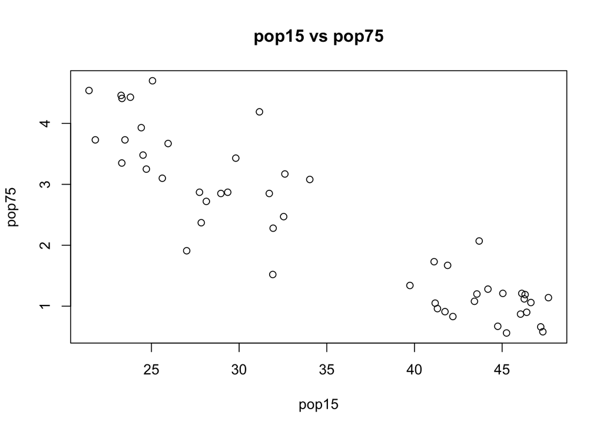

```r
plot(LifeCycleSavings$pop15, LifeCycleSavings$pop75, xlab = 'pop15', ylab = 'pop75', main = 'pop15 vs pop75')
```

# (2) Make an interesting observation about the relationship between

# pop15 and pop75 based on your plot.

# (something that you couldn’t see with the calculations so far.) (1 pt)

```r
# Your answer here
#There seems to be a relationship between the percentage of the Population under the age of 15 and the amount
#of the population over the age of 75. The higher the percentage of people under the age of 15, the lower
#percentage of people over 75.
```

# (3) Based on our analysis so far, what interesting question about the LifeCycleSavings data

# would you like to answer, but don’t yet know how to do it? (1 pt)

```r
# Your answer here
#I would like to see if there is a relationship between the amount of population over the age of 75
#and the amount of personal savings. Does more people over the age of 75 mean there are higher amounts
#of personal savings?
```

# Part 3. Random number generators

# For the remainder of this assignment we will work with

# one of the random number generators in R.

# (1) Use you UIN number to set the seed in the set.seed() function. (1 pt)

# Your code here

```r
set.seed(660694484)
```

# (2) Generate a vector called “normsample” containing 1000 random samples from a

# normal distribution with mean 2 and standard deviation 1. (1 pt)

# Your code here

```r
normsample <- rnorm(1000, mean=2, sd=1)
```

# (3) Calculate the mean and standard deviation of the normsample. (2 pts)

# Your code here

```r
mean(normsample)
```

```
## [1] 2.016063
```

```r
sd(normsample)
```

```
## [1] 1.002991
```

# (4) Use logical operations (>,<,==,….) to calculate

# the fraction of the values in “normsample” that are more than 3. (1 pt)

# Your code here

```r
length(which(normsample>3))
```

```
## [1] 168
```

```r
168/1000
```

```
## [1] 0.168
```

# (8). Find the area under the normal(2, 1) curve to the right of 3.

# This should be the probability of getting a random value more than 3.

# (Hint: Look up the help for rnorm. You will see a few other functions listed.

# Use one of them to figure out about what answer you should expect.)

# What value do you expect?

# I would expect about 16.8%.

# R returned the value 15.9%

# Why might they be different? (3 pts)

# The values may be different based on a few things. They may be that the random values will differ based

# on a vector of different lengths. In this case, this results in a lower probability of giving a value

# more than three. Probabiliy does not neccesarily predict observed results.

# Your code here

```r
help(rnorm)
pnorm(3, mean=2, sd=1, lower.tail = FALSE)
```

```
## [1] 0.1586553
```